# Spreadsheets and Table

To motivate the use of a relational databases, lets start by looking at a table.

:point_right: Go to betydb.org and enter “Miscanthus Yield” into the search box and click the search glass icon.

Lets review the information in this table.

- Site with city
- Date + time + timezone
- Species + common name
- Cultivar
- Trait
- Mean (with units)
- Method
- Entity

Now click the “Download Results” button. This will download a .csv file. A .csv file is a table where each column is defined by a comma, e.g. a 3x3 matrix would be formatted thus:

```
row 1 col 1, row 1 col 2, row 1 col 3
row 2 col 1, row 2 col 2, row 2 col 3
row 3 col 1, row 3 col 2, row 3 col 3
```

*a brief note about csv files*

By default, many computers will open the csv file directly into a [spreadsheet program](https://en.wikipedia.org/wiki/spreadsheet) like Microsoft Excel or OpenOffice Calc. But because it is a text file, you can also open it in a [text editor](https://en.wikipedia.org/wiki/Text_editor) like Notepad, nano, or emacs.

It can also be easily read by any software or parsed at the command line using tools like `cut` and `sed`. Unlike xml and json, it is more intuitive for a human to read.

# Data Cleaning

- Download OpenRefine from http://openrefine.org/download.html

# Relational Databases and SQL

## Relational Databases

### Data Normalization

example:

download from betydb.org/search?genus=Miscanthus&trait=Yield review table where are redundancies

### Tables & Schemas

[figure not shown]

A simplified entity–relationship diagram for key tables in Biofuel Ecophysiological Traits and Yields database (BETYdb).

### Schemas

## SQL

### Basic commands

SELECT WHERE JOIN

LIMIT ORDER BY GROUP BY AND OR MIN MAX AVG SUM COUNT LIKE

### Types of Joins

## Database Management Systems

### Common software

MySQL, PostgreSQL, Oracle,

Access??

### Connecting to a database server

connection parameters host login user database

.pgpass

psql -U bety -d bety -h localhost

### R: RPostgreSQL and dplyr

### APIs

get put delete

### json data structures

### R traits package

## Real World Examples

### A Simple database

- Download data from BETYdb
- Discuss how to normalize it

### Advanced: BETYdb

- Full Schema betydb.org/schemas
- How would you query all of the planting dates associated with a trait record?

## Real World Application: the Biofuel Ecophysiological Traits and Yields database

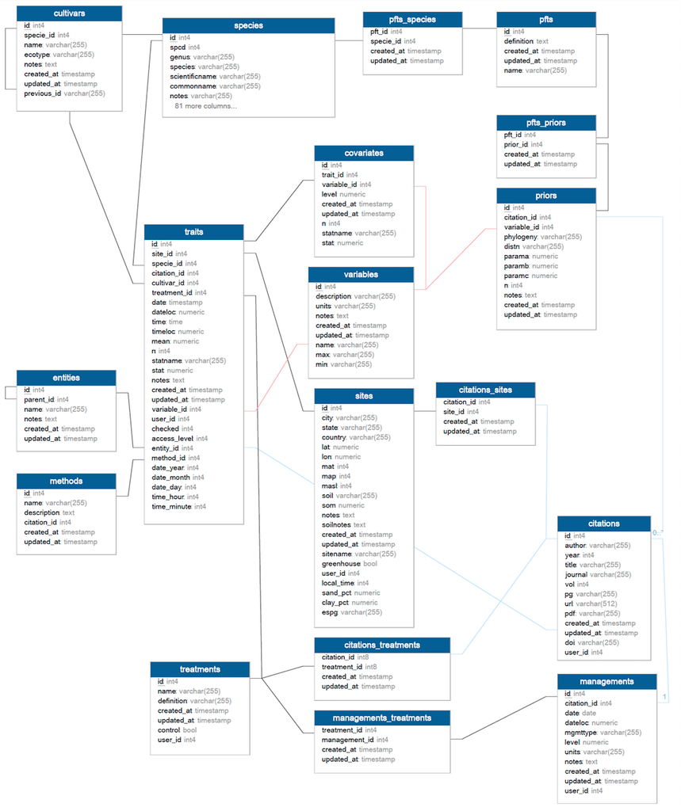

Summary BETYdb schema

We have created ‘views’ to make it easier to query data from multiple tables. For example, to lookup the name and location of a site or the names and units of variables. The following query joins multiple tables, and is based on the yieldsview table:

```sql
SELECT 'yields'::character(10) AS result_type,
    yields.id,
    yields.citation_id,
    yields.site_id,
    yields.treatment_id,
    sites.sitename,
    sites.city,
    st_y(st_centroid(sites.geometry)) AS lat,
    st_x(st_centroid(sites.geometry)) AS lon,
    species.scientificname,
    species.commonname,
    species.genus,
    species.id AS species_id,
    yields.cultivar_id,
    citations.author,
    citations.year AS citation_year,
    treatments.name AS treatment,
    yields.date,
    date_part('month'::text, yields.date) AS month,
    date_part('year'::text, yields.date) AS year,
    variables.name AS trait,
    variables.description AS trait_description,
    yields.mean,
    variables.units,
    yields.n,
    yields.statname,
    yields.stat,
    yields.notes,
   FROM ((((((yields
     LEFT JOIN sites ON ((yields.site_id = sites.id)))
     LEFT JOIN species ON ((yields.specie_id = species.id)))
     LEFT JOIN citations ON ((yields.citation_id = citations.id)))
     LEFT JOIN treatments ON ((yields.treatment_id = treatments.id)))
     LEFT JOIN variables ON (((variables.name)::text = 'Ayield'::text)))
     LEFT JOIN users ON ((yields.user_id = users.id)));
```

For more information, see the [BETYdb data access documentation](https://pecan.gitbooks.io/betydb-data-access/content/sqlqueries.html)

## references and further reading

https://www.dataquest.io/blog/sql-basics/